# Figures 1&2

Imports

```r
library(tidyverse)
library(readxl)
library(ggpubr)
library(rstatix)
```

```r
library(igraph)
library(readxl)
```

Variables and data

```r
#colors from iwanthue https://medialab.github.io/iwanthue/?utm_source=Nature+Briefing&utm_campaign=e0c3e024d4-briefing-dy-20211006&utm_medium=email&utm_term=0_c9dfd39373-e0c3e024d4-44542065
colors <- read_tsv("data/colors_fancy.txt", col_names = F, show_col_types = FALSE) %>% pull()
mygrey <- "#F5F5F5"

#import
my_file_pos <- "data/2_Bret_screen_final.xlsx"
#literature interactions
my_file_interactions <- "data/Peroxisomal_interactions_across_dbs_final.xlsx"
#import of Yifrach Dataset
#Gene / FinalScore / DetectionFrequency
my_yifrach_genes <- "data/yifrach_adapted.xlsx"
#ePI interactome
ePI_file <- "data/ePI_edgelist.csv"
#random sampling lcc
my_random_lcc_file <- "data/1000_degree_matched_random_samples_LCC_disease_genes_in_interactome.xlsx"
#data on degree of ePI members
my_intExt_degree_file <- "data/characteristics_ePI_degrees.csv"
#contains comparison of lit vs bret interactions
my_file_mapping <- "data/mapper.xlsx" #mapping from entrez to symbol
my_file_function <- "data/9_genesFunction.txt"  #functions of peroxisomal proteins

#output
my_heatmap_file = "output/figure2/2B_heatmap_positives.pdf" #output for heatmap file
```

Genes from the results

```r
positives_original <- read_xlsx(my_file_pos, col_names=TRUE)
g_isoforms <- sort(union(unique(positives_original$ProteinA), unique(positives_original$ProteinB)))
g_isoforms
```

```
##  [1] "ABCD1"    "ABCD2"    "ABCD3b"   "ABCD4"    "ACAA1a"   "ACAA1b"
##  [7] "ACAD11"   "ACBD5"    "ACOT1"    "ACOT4"    "ACOT8"    "ACOX1"
## [13] "ACOX2"    "ACOX3"    "ACSL4"    "ACSL5"    "ACSL6"    "AGPS"
## [19] "AGXT"     "ALDH3A2"  "AMACR"    "ATAD1"    "BAAT"     "CAT"
## [25] "CRAT"     "CROT"     "DAO"      "DDO"      "DECR2"    "DHRS4"
## [31] "DNM1L"    "ECH1"     "ECI2"     "EHHADH"   "EPHX2"    "FAR1"
## [37] "FAR2"     "FIS1"     "FNDC5"    "GNPAT"    "GSTK1a"   "GSTK1b"
## [43] "HACL1"    "HAO1"     "HAO2"     "HMGCL"    "HMGCR"    "HSD17B4"
## [49] "IDE"      "IDH1"     "IDI1"     "IDI2"     "MFF"      "MLYCD"
## [55] "MPV17"    "MTARC2"   "MVK"      "NOS2"     "NUDT12"   "PECR"
## [61] "PEX1"     "PEX10v1"  "PEX10v2"  "PEX11A"   "PEX11B"   "PEX11G"
## [67] "PEX12"    "PEX13"    "PEX14"    "PEX16"    "PEX19"    "PEX2"
## [73] "PEX26"    "PEX3"     "PEX5b"    "PEX5d"    "PEX6"     "PEX7"
## [79] "PHYH"     "PIPOX"    "PMVK"     "PRDX1"    "PRDX5"    "PTGR3"
## [85] "PXMP2"    "PXMP4"    "PXT1"     "SCP2v1"   "SCP2v2"   "SERHL"
## [91] "SLC25A17" "SLC27A2"  "SOD1"     "SOD2v2"   "SOD2vX"   "TMEM135"
## [97] "TRIM37"   "TYSND1"
```

Prepare everything for heatmap plotting

```r
#read all positives
positives <- read_xlsx(my_file_interactions) %>%
  replace(is.na(.), 0)

#load mapper and prepare
mapper <- read_excel(my_file_mapping)
mapper_red <- mapper %>%
  dplyr::select('Symbol[table]', 'EntrezID[mapper]') %>%
  group_by(`Symbol[table]`,`EntrezID[mapper]`) %>%
  distinct() %>%
  ungroup()

#map data
#code data
#found in ucrinteractome = 1
#found in iBRET = 2
#found in both = 3
#found nothing = 0
positives_mapped <- positives %>%
  left_join(mapper_red, by = c("Interactor_A" = "EntrezID[mapper]")) %>%
  left_join(mapper_red, by = c("Interactor_B" = "EntrezID[mapper]")) %>%
  arrange(Interactor_A) %>%
  dplyr::rename(proteinA = 'Symbol[table].x', proteinB = 'Symbol[table].y') %>%
  mutate(class = if_else(InteractomeUCR == 1,if_else(iBret == 1,3,1),if_else(iBret == 1,2,0)))

positives_mapped %>% group_by(class) %>% count()
```

```
## # A tibble: 3 × 2
## # Groups:   class [3]
##   class     n
##   <dbl> <int>
## 1     1    21
## 2     2   333
## 3     3    44
```

```r
#do we have all proteins? n = 92 (without isoforms)
pg_withoutIso <- sort(union(unique(positives_mapped$proteinB), unique(positives_mapped$proteinA)))

pg_withoutIso
```

```
##  [1] "ABCD1"    "ABCD2"    "ABCD3"    "ABCD4"    "ACAA1"    "ACAD11"
##  [7] "ACBD5"    "ACOT1"    "ACOT4"    "ACOT8"    "ACOX1"    "ACOX2"
## [13] "ACOX3"    "ACSL4"    "ACSL5"    "ACSL6"    "AGPS"     "AGXT"
## [19] "ALDH3A2"  "AMACR"    "ATAD1"    "BAAT"     "CAT"      "CRAT"
## [25] "CROT"     "DAO"      "DDO"      "DECR2"    "DHRS4"    "DNM1L"
## [31] "ECH1"     "ECI2"     "EHHADH"   "EPHX2"    "FAR1"     "FAR2"
## [37] "FIS1"     "FNDC5"    "GNPAT"    "GSTK1"    "HACL1"    "HAO1"
## [43] "HAO2"     "HMGCL"    "HMGCR"    "HSD17B4"  "IDE"      "IDH1"
## [49] "IDI1"     "IDI2"     "MFF"      "MLYCD"    "MPV17"    "MTARC2"
## [55] "MVK"      "NOS2"     "NUDT12"   "PECR"     "PEX1"     "PEX10"
## [61] "PEX11A"   "PEX11B"   "PEX11G"   "PEX12"    "PEX13"    "PEX14"
## [67] "PEX16"    "PEX19"    "PEX2"     "PEX26"    "PEX3"     "PEX5"
## [73] "PEX6"     "PEX7"     "PHYH"     "PIPOX"    "PMVK"     "PRDX1"
## [79] "PRDX5"    "PTGR3"    "PXMP2"    "PXMP4"    "PXT1"     "SCP2"
## [85] "SERHL"    "SLC25A17" "SLC27A2"  "SOD1"     "SOD2"     "TMEM135"
## [91] "TRIM37"   "TYSND1"
```

JACCARD Similarity for isoforms Are their interaction partners more similar than other proteins?

Lets get the isoforms that are included in the screen

```r
setdiff(g_isoforms, pg_withoutIso) -> i
setdiff(i, "ABCD3b") -> isos #we do not have a partner for ABCD3b -> exclude it here
isos
```

```
##  [1] "ACAA1a"  "ACAA1b"  "GSTK1a"  "GSTK1b"  "PEX10v1" "PEX10v2" "PEX5b"
##  [8] "PEX5d"   "SCP2v1"  "SCP2v2"  "SOD2v2"  "SOD2vX"
```

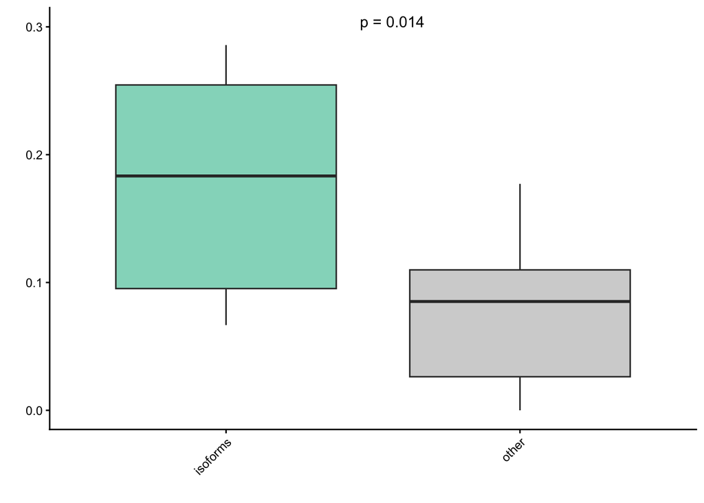

```r
p_inter_with_iso <- positives_original %>%
  dplyr::select(ProteinA, ProteinB)

p_graph_with_iso <- graph_from_edgelist(as.matrix(p_inter_with_iso), directed = FALSE)
#create graph without the isoforms in order to avoid redundancy
p_graph_without_iso <- p_graph_with_iso - isos

#jaccard similarity for the 6 isoforms investigated
#mean((colSums(jacc_matr)-1)/(nrow(jacc_matr)-1))

#isoform_pairs
accaa1 <- c("ACAA1a","ACAA1b")
gstk1 <- c("GSTK1a","GSTK1b")
pex10 <- c("PEX10v1","PEX10v2")
pex5 <- c("PEX5b","PEX5d")
scp2 <- c("SCP2v1","SCP2v2")
sod2 <- c("SOD2v2","SOD2vX" )

isoform_pairs <- list(accaa1, gstk1, pex10, pex5, scp2, sod2)

#calculate jaccard similarity for each pair of isoforms
jacc_isoforms <- sapply(isoform_pairs, function(x) similarity(p_graph_with_iso, x, method="jaccard"))

#jaccard similarity for all other pairs without isoforms
jacc_allother <- similarity(p_graph_without_iso, method="jaccard")
jacc_tbl <- tibble(jaccard = (colSums(jacc_allother)-1)/(nrow(jacc_allother)-1), cat = "other")

#bind pairwise jaccsimilarity of isoforms and others together
jacc_all <- rbind(jacc_tbl, tibble(jaccard = jacc_isoforms[2,], cat = "isoforms"))

jaccard_plot <- jacc_all %>%
  ggplot(aes(x = cat, y=jaccard)) +
  geom_boxplot(aes(fill = cat)) +
  theme_classic() +
  labs(x = "", y = "") +
  scale_fill_manual(values = c("#94d9c5", "#D3D3D3")) + stat_compare_means(method = "wilcox.test", label.x = 1.5, label.y = 0.3, label = "p.format") +
  theme(axis.text.x = element_text(angle = 45,hjust = 1,vjust = 1), legend.position = "none")

ggsave("output/figure1/jaccard_isoform_boxplot.pdf", plot = jaccard_plot, width = 3, height = 5, units = "cm", scale = 1.6)
jaccard_plot
```

```r
jacc_all %>%
  group_by(cat) %>%
  summarise(mean = mean(jaccard), median = median(jaccard), sd = sd(jaccard))
```

```
## # A tibble: 2 × 4
##   cat        mean median     sd
##   <chr>     <dbl>  <dbl>  <dbl>
## 1 isoforms 0.177  0.183  0.0948
## 2 other    0.0762 0.0851 0.0465
```

Is the higher Jaccard Index for isoforms driven by PPI to the import receptors PEX5, PEX7, PEX19?

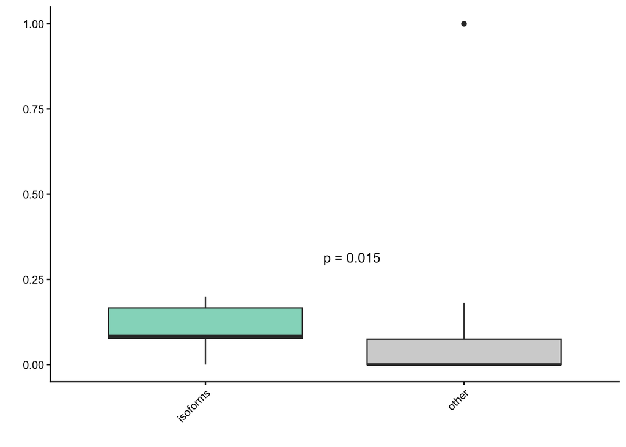

```r
#lets remove PPI to PEX5, PEX7 and PEX19 and repeat analysis of Jaccard Index
p_graph_with_iso_withoutImport <- p_graph_with_iso - c("PEX5b", "PEX5d", "PEX7", "PEX19")
p_graph_without_iso_withoutImport <- p_graph_without_iso - c("PEX7", "PEX19")

jacc_isoforms_withoutImport <- sapply(list(accaa1, gstk1, pex10, scp2, sod2), function(x) similarity(p_graph_with_iso_withoutImport, x, method="jaccard"))

jacc_allother_withoutImport <- similarity(p_graph_without_iso_withoutImport, method="jaccard")

jacc_all_withoutImport <- rbind(tibble(jaccard = jacc_allother_withoutImport[2,], cat="other"), tibble(jaccard = jacc_isoforms_withoutImport[2,], cat="isoforms"))

jaccard_plot <- jacc_all_withoutImport %>%
  ggplot(aes(x = cat, y=jaccard)) +
  geom_boxplot(aes(fill = cat)) +
  theme_classic() +
  labs(x = "", y = "") +
  scale_fill_manual(values = c("#94d9c5", "#D3D3D3")) + stat_compare_means(method = "wilcox.test", label.x = 1.5, label.y = 0.3, label = "p.format") +
  theme(axis.text.x = element_text(angle = 45,hjust = 1,vjust = 1), legend.position = "none")

#ggsave("../Manuskript/Figures/Figure1/jaccard_isoform_boxplot.pdf", plot = jaccard_plot, width = 3, height = 5, units = "cm", scale = 1.6)
print(jaccard_plot)
```

```r
jacc_all_withoutImport %>%
  group_by(cat) %>%
  summarise(mean = mean(jaccard), median = median(jaccard), sd = sd(jaccard))
```

```
## # A tibble: 2 × 4
##   cat        mean median     sd
##   <chr>     <dbl>  <dbl>  <dbl>
## 1 isoforms 0.105  0.0833 0.0792
## 2 other    0.0427 0      0.119
```

PPI Matrix for isoforms

```r
isoform_pairs
```

```
## [[1]]
## [1] "ACAA1a" "ACAA1b"
##
## [[2]]
## [1] "GSTK1a" "GSTK1b"
##
## [[3]]
## [1] "PEX10v1" "PEX10v2"
##
## [[4]]
## [1] "PEX5b" "PEX5d"
##
## [[5]]
## [1] "SCP2v1" "SCP2v2"
##
## [[6]]
## [1] "SOD2v2" "SOD2vX"
```

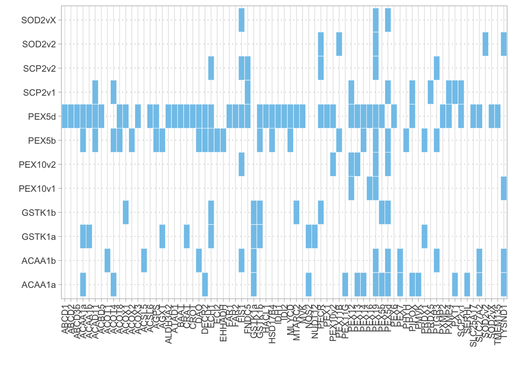

```r
getIsoformPPIforMatrix <- function(isoform, g) {
  return( tibble(isoform = isoform, interactors = neighbors(g, v= isoform)$name) %>% distinct())
}

isoform_ppi <- lapply(isos, function(x) getIsoformPPIforMatrix(x, p_graph_with_iso)) %>% bind_rows %>% mutate(class = "ppi")

p<- isoform_ppi %>% ggplot() +
  geom_tile(aes(x = interactors, y = isoform, fill = class), color="white") +
  scale_fill_manual(values=colors[4], name="", na.value=mygrey) +
  theme_light() +
  theme(panel.spacing = unit(0.5, "lines"),axis.text.x = element_text(angle = 90, hjust = 1, vjust = 0.5),panel.grid.major.y = element_line(colour = "grey", linetype ="dotted")) +
  labs(x="", y="") +
  guides(fill = "none")

ggsave("output/figure1/isoform_ppi_matrix.pdf", plot = p, width = 13, height=4, scale = 1.6, units = "cm")

print(p)
```

Comparison with yifrach dataset

```r
yifrach_genes <- read_excel(my_yifrach_genes) %>%
  dplyr::select(`Gene name update`, DetectionFrequency, FinalScore) %>%
  dplyr::rename("Gene" = `Gene name update`)

yifrach_genes %>%
  mutate(study = if_else(Gene %in% pg_withoutIso,"y","n")) %>%
  group_by(study, DetectionFrequency) %>%
  count()
```

```
## # A tibble: 4 × 3
## # Groups:   study, DetectionFrequency [4]
##   study DetectionFrequency     n
##   <chr> <chr>              <int>
## 1 n     High                  23
## 2 n     Low                   81
## 3 y     High                  73
## 4 y     Low                   19
```

Heatmap of ePI (iBRET positives plus literature interactions of all pex associated genes according to Yifrach et al)

1. Read ePI interactions

```r
ePI_edge <- read_csv(ePI_file, show_col_types = FALSE) %>%
  dplyr::select(Symbol_A, Symbol_B) %>%
  dplyr::rename(proteinA = "Symbol_A", proteinB = "Symbol_B")

ePI_graph <- graph_from_edgelist(as.matrix(ePI_edge), directed = FALSE)
```

2. some operations that prepare the data specifically, this sets a lower triangle for heatmap plotting

```r
#create igraph with bret interactions only
pex_bret <- graph_from_edgelist(as.matrix(positives_mapped %>% filter(class == 2) %>% dplyr::select(proteinA, proteinB)), directed = FALSE)
#create igraph with literature interactions only
pex_lit <- graph_from_edgelist(as.matrix(positives_mapped %>% filter(class == 1) %>% dplyr::select(proteinA, proteinB)), directed = FALSE)
#create igraph that contains only ppi detected by ibret and already known
pex_both <- graph_from_edgelist(as.matrix(positives_mapped %>% filter(class == 3) %>% dplyr::select(proteinA, proteinB)), directed = FALSE)

#add class eg whether found with ibret or literature evidence or both
inter_both <- as_data_frame(igraph::intersection(ePI_graph, pex_both, keep.all.vertices = FALSE)) %>% mutate(class = 3)
inter_bret <- as_data_frame(igraph::intersection(ePI_graph, pex_bret, keep.all.vertices = FALSE)) %>% mutate(class = 2)
inter_lit <- as_data_frame(igraph::intersection(ePI_graph, pex_lit, keep.all.vertices = FALSE)) %>% mutate(class = 1)
inter_ePI <- as_data_frame(igraph::difference(ePI_graph, igraph::union(pex_bret, pex_both, pex_lit))) %>% unique() %>% mutate(class = 1)
ePI_edge_cl <- rbind(inter_both, inter_bret, inter_lit, inter_ePI) %>% dplyr::rename(proteinA = "from", proteinB = "to")
rm(inter_both,inter_bret, inter_lit, inter_ePI)

ePI_edge_cl -> posA
ePI_edge_cl %>% dplyr::select(proteinB, proteinA, class) %>% rename(proteinA = "proteinB", proteinB = "proteinA") -> posB

#bind everything together and create temp. dataframe.
df = rbind(posA, posB)

#create a matrix out of the data frame
df_rearranged <- df %>% group_by(proteinA, proteinB) %>% unique %>% ungroup %>% arrange(proteinA) %>% pivot_wider(names_from = proteinA, values_from = class) %>% arrange(proteinB)

df_matr <- as.matrix(dplyr::select(df_rearranged,-proteinB))
rownames(df_matr) <- df_rearranged$proteinB

#convert back to data frame but only the lower triangle
ut <- lower.tri(df_matr, diag = TRUE)
df_lower <- data.frame(proteinB = rownames(df_matr)[row(df_matr)[ut]], proteinA = colnames(df_matr)[col(df_matr)[ut]], class = df_matr[ut])

#clean
rm(df)
```

Heatmap plotting

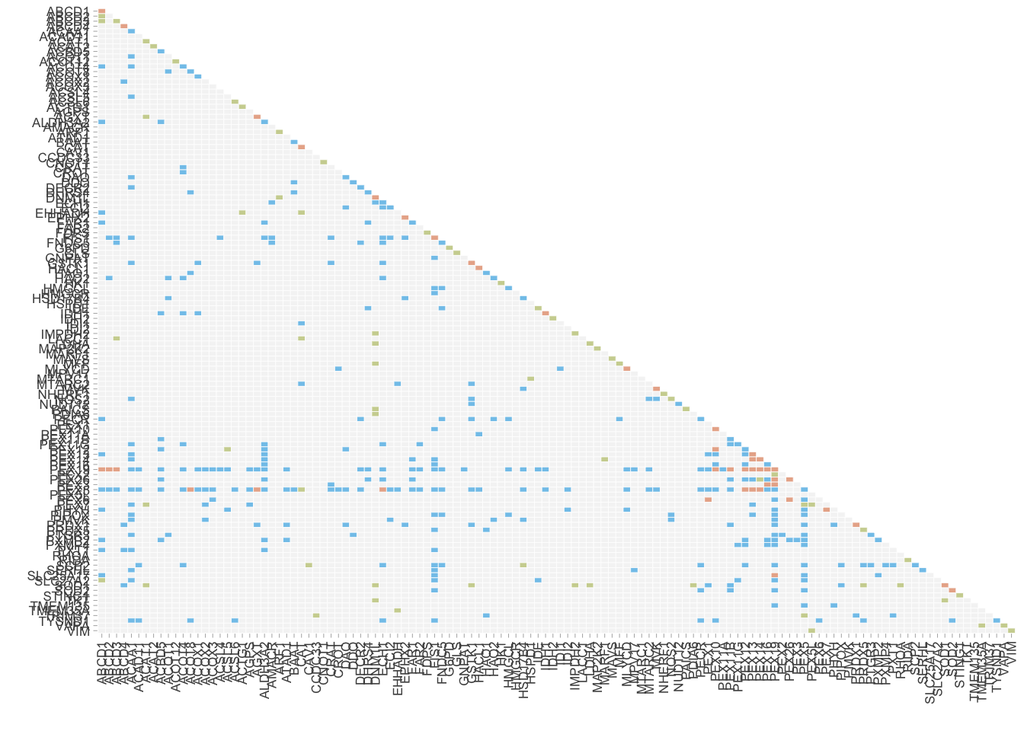

```r
#we need the degrees to plot only the top n hub proteins
ePI_degree <- as_tibble(rownames_to_column(as.data.frame(degree(ePI_graph, loops = FALSE)), var="symbol")) %>% dplyr::rename("degree" = `degree(ePI_graph, loops = FALSE)`)
prot_to_plot <- ePI_degree %>% arrange(desc(degree)) %>% head(n=20) %>% pull(symbol)

p <- df_lower %>%
  #filter(!is.na(class)) %>%
  mutate(class = case_match(class, 1 ~ "Literature", 2 ~ "iBRET", 3 ~ "Both", NA ~ "not interacting")) %>%
  mutate(proteinBrev = factor(proteinB, levels = rev(unique(df_lower$proteinB)))) %>%
  ggplot() +
  geom_tile(aes(x = proteinA, y = proteinBrev, fill= class), color="white") +
  theme_light(base_size = 8) +
  scale_fill_manual(values=c("Both" = colors[5], "iBRET" = colors[4], "Literature" = colors[3], "not interacting" = mygrey), name="") +
  #scale_x_discrete(breaks = prot_to_plot) +
  #scale_y_discrete(breaks = prot_to_plot) +
    theme(
        panel.border = element_rect(linetype = "blank", fill = NA),
        panel.grid = element_line(colour = "white", linetype = "dotted"),
        panel.spacing = unit(0.3, "lines"),
        axis.text.x = element_text(
            angle = 90,
            hjust = 1,
            vjust = 0.5
        ),
    ) +
    labs(x = "", y = "") +
    guides(fill = "none")

ggsave(my_heatmap_file, plot = p, width = 14.5, height=14.5, scale = 1.4, units = "cm")
p
```

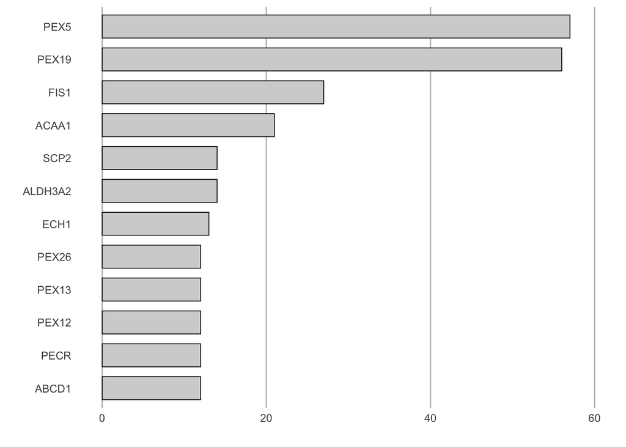

```r
#exclude literature interactions
pex_graph <- graph_from_edgelist(as.matrix(positives_mapped %>% filter(class != 1) %>%
                                             dplyr::select(proteinA, proteinB)), directed = FALSE)
pex_degree <- as_tibble(rownames_to_column(as.data.frame(degree(pex_graph, loops = FALSE)), var="symbol")) %>% dplyr::rename("degree" = `degree(pex_graph, loops = FALSE)`)

p_bar <- pex_degree %>%
  mutate(ranking = dense_rank(dplyr::desc(degree))) %>%
  filter(ranking < 8) %>%
  ggplot(aes(x = reorder(symbol, degree), y = degree)) +
  geom_bar(stat = "identity", fill="#D3D3D3", color="black", width=0.7, linewidth=0.3) +
  theme_minimal() +
  theme(panel.border = element_rect(linetype = "blank", fill = NA),
        panel.grid = element_line(colour = "white"),
        panel.grid.major.x = element_line(colour = "grey")) +
  scale_y_continuous(limits = c(0,60)) +
  labs(x = "", y = "") +
  coord_flip()
p_bar
```

```r
ggsave("output/figure1/top_hubs.pdf", plot = p_bar, width = 3.5, height = 3.5, units = "cm", scale = 1.5)
```

Fig 1C degree distribution

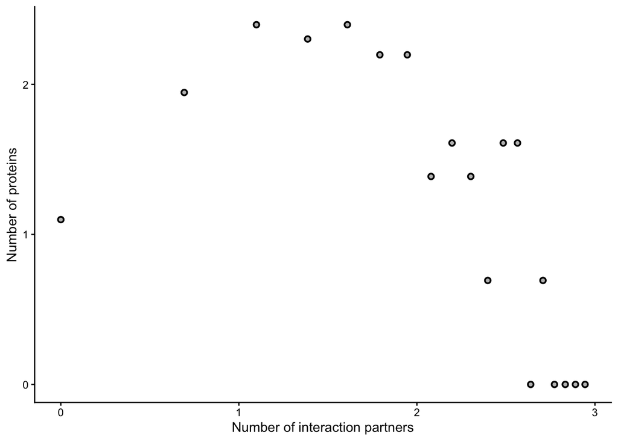

```r
# List of degrees
G.degrees <- degree(pex_graph)

# Let's count the frequencies of each degree
G.degree.histogram <- as.data.frame(table(G.degrees))

# Need to convert the first column to numbers, otherwise
# log-log will not work
G.degree.histogram[,1] <- as.numeric(G.degree.histogram[,1])

# Now, plot it!
p <- ggplot(G.degree.histogram, aes(x = log(G.degrees), y = log(Freq))) +
  geom_point(shape = 21, colour = "black", fill = "grey", stroke = 1) +
  scale_x_continuous("Number of interaction partners") +
  scale_y_continuous("Number of proteins", breaks = c(0,1,2,3)) +
  theme_classic()
ggsave("output/figure1/degree_distribution.pdf", plot = p, width = 4, height = 3, units = "cm", scale = 2)
p
```

Check for power law distribution

```r
library(poweRlaw)
deg <- G.degrees[G.degrees > 0]
pl_model <- displ$new(deg)  # discrete power law

#xmin
est_pl <- estimate_xmin(pl_model)
pl_model$setXmin(est_pl)

#alpha
pl_model$setPars(est_pl$pars)
pl_model$pars
```

```
## [1] 2.638791
```

```r
#goodness of fit
bs_pl <- bootstrap_p(pl_model, no_of_sims = 1000, threads = 2)
```

```
## Expected total run time for 1000 sims, using 2 threads is 8 seconds.
```

```r
bs_pl$p
```

```
## [1] 0.107
```

```r
#p ≥ 0,1 → Power law plausible
#p < 0,05 → Power law unlikely
```

Compare to log-normal distribution

```r
ln_model <- dislnorm$new(deg)
#ximn
ln_model$setXmin(pl_model$getXmin())
ln_model$setPars(estimate_pars(ln_model))

#likelihood test
comp <- compare_distributions(pl_model, ln_model)
#comp

#results
comp$test_statistic
```

```
## [1] -0.6802448
```

```r
comp$p_two_sided
```

```
## [1] 0.4963495
```

```r
# Save as PNG using png() and dev.off()
png("output/figure2/PI_distr_comparison.png")
#png("output/figure2/ePI_distr_comparison.png")

#plot both models (eg powerlaw vs log-normal)
plot(pl_model, main = "Degree distribution")
lines(pl_model, col = "red")
lines(ln_model, col = "blue")

legend("bottomleft",
       legend = c("Power law", "Log-normal"),
       col = c("red", "blue"),
       lty = 1)
# Close the PNG device
dev.off()
```

Load edgelist of extendedPI and plot degree distribution

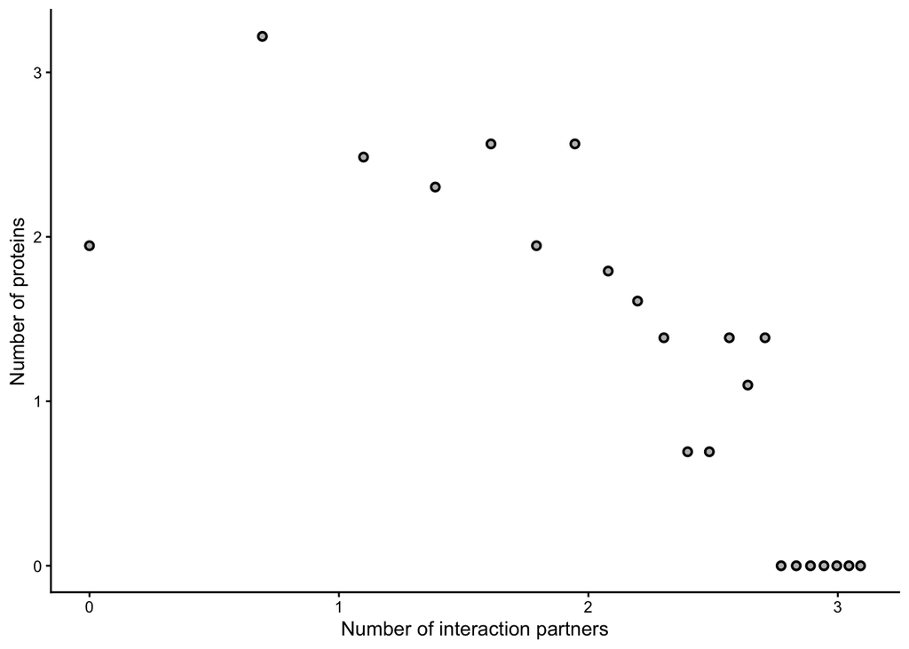

```r
# List of degrees
G.degrees_ePI <- degree(ePI_graph)

# Let's count the frequencies of each degree
G.degree_ePI.histogram <- as.data.frame(table(G.degrees_ePI))

# Need to convert the first column to numbers, otherwise
# the log-log thing will not work (that's fair...)
G.degree_ePI.histogram[,1] <- as.numeric(G.degree_ePI.histogram[,1])

# Now, plot it!
p <- ggplot(G.degree_ePI.histogram, aes(x = log(G.degrees_ePI), y = log(Freq))) +
  geom_point(shape = 21, colour = "black", fill = "grey", stroke = 1) +
  scale_x_continuous("Number of interaction partners") +
  scale_y_continuous("Number of proteins", breaks = c(0,1,2,3)) +
  theme_classic()
ggsave("output/figure2/degree_distributio_ePI.pdf", plot = p, width = 4, height = 3, units = "cm", scale = 2)
p
```

Compare distribution

```r
deg <- G.degrees_ePI[G.degrees_ePI > 0]

pl_model <- displ$new(deg)  # discrete power law

#xmin
est_pl <- estimate_xmin(pl_model)
pl_model$setXmin(est_pl)

#alpha
pl_model$setPars(est_pl$pars)
pl_model$pars
```

```
## [1] 2.913979
```

```r
#goodness of fit
bs_pl <- bootstrap_p(pl_model, no_of_sims = 1000, threads = 2)
```

```
## Expected total run time for 1000 sims, using 2 threads is 9.58 seconds.
```

```r
bs_pl$p
```

```
## [1] 0.337
```

```r
#p ≥ 0,1 → Power law plausible
#p < 0,05 → Power law unlikely
```

Compare to log-normal distribution

```r
ln_model <- dislnorm$new(deg)
#ximn
ln_model$setXmin(pl_model$getXmin())
ln_model$setPars(estimate_pars(ln_model))

#likelihood test
comp <- compare_distributions(pl_model, ln_model)
#comp

#results
comp$test_statistic
```

```
## [1] -0.2503179
```

```r
comp$p_two_sided
```

```
## [1] 0.8023415
```

```r
# Save as PNG using png() and dev.off()
#png(paste(path_to, "PI_distr_comparison.png", sep=""))
png("output/figure2/ePI_distr_comparison.png")

#plot both models (eg powerlaw vs log-normal)
plot(pl_model, main = "Degree distribution")
lines(pl_model, col = "red")
lines(ln_model, col = "blue")

legend("bottomleft",
       legend = c("Power law", "Log-normal"),
       col = c("red", "blue"),
       lty = 1)
# Close the PNG device
dev.off()
```

[output not shown]

[figure not shown]

```r
ggsave("output/figure2/lcc_disease_module_histogram.pdf", plot = p, width = 4.5, height = 3, units = "cm", scale = 2)
p
```

Read functions

```r
#read genes with their respective functions and sort
pex_functions <- read_tsv(my_file_function, show_col_types = FALSE)
#get all functions in separate cols and rows
fun_genes <- pex_functions %>%
  dplyr::select(symbol, geneFunction) %>%
  separate_longer_delim(geneFunction, delim = "; ")

#rowwise() %>%
#  mutate(n_interactors = length(unlist(str_split(pex_interactor, ","))))

fun_genes_counted <- fun_genes %>%
  count(geneFunction) %>%
  arrange(desc(n))
```

Plot counts of gene function as bar plots

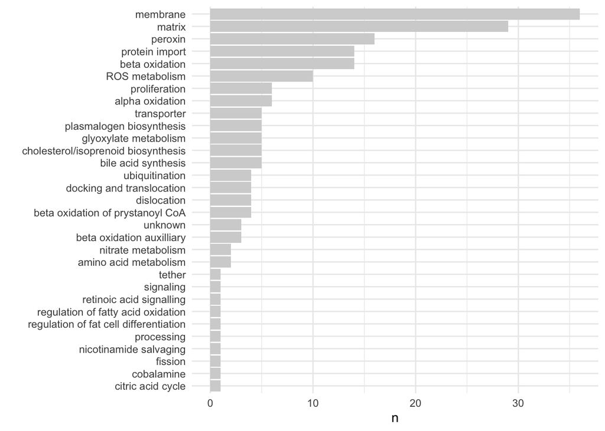

```r
fun_genes_counted %>%
  ggplot(aes(y=reorder(geneFunction,n), x=n)) +
  geom_bar(stat="identity", fill="#D3D3D3") +
  labs(y="") +
  theme_minimal()
```

Fig 1E: Comparison of network parameters (degree, betweenness centrality) of peroxins with other peroxisomal proteins

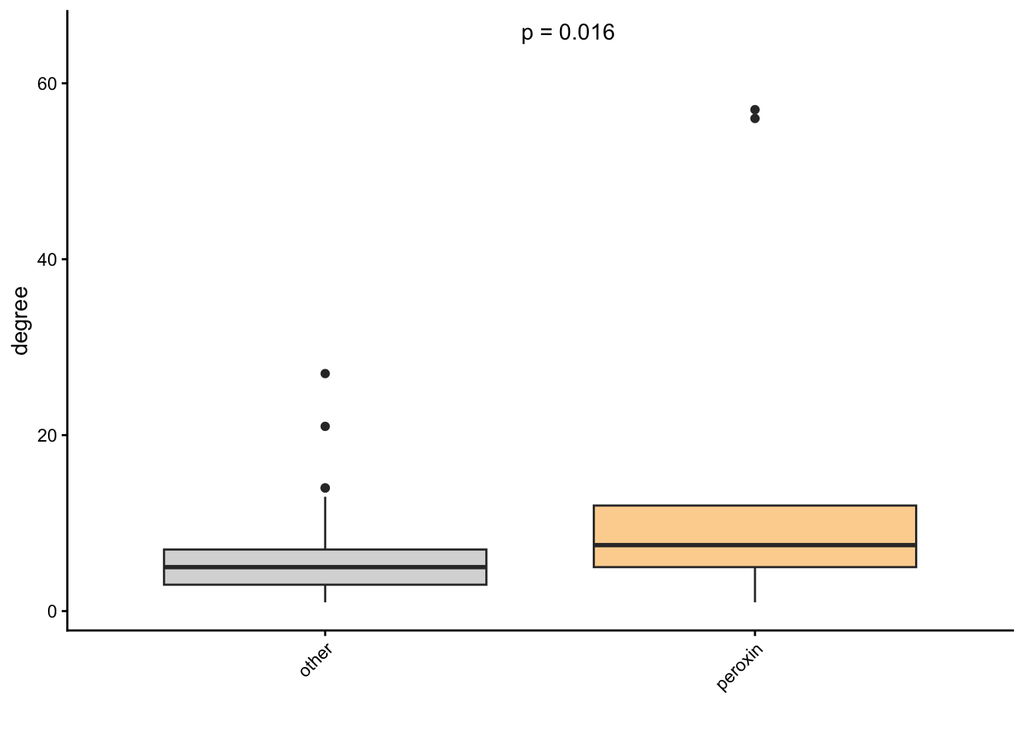

```r
#join degree tibble with function and plot boxgraph
#functions that should be compared
col_peroxins <- c("peroxin" = "#FDD49F", "other" = "#D9D9D9")

peroxins <- fun_genes %>%
  filter(geneFunction == "peroxin") %>%
  pull(symbol)

fun_pl <- fun_genes %>%
  mutate(gene_class = if_else(symbol %in% peroxins, "peroxin", "other")) %>%
  dplyr::select(symbol, gene_class) %>%
  unique() %>%
  left_join(pex_degree, by = join_by(symbol == symbol))

p <- fun_pl %>%
  filter(!is.na(degree)) %>%
  ggplot(aes(x = gene_class, y=degree)) +
  geom_boxplot(aes(fill = gene_class), stat="boxplot") +
  scale_fill_manual(values = col_peroxins) +
  theme_classic() +
  theme(axis.text.x = element_text(angle = 45,hjust = 1,vjust = 1), legend.position = "none") +
  labs(x = "") +
  stat_compare_means(method = "wilcox.test", label.x = 1.5, label.y = 65, label = "p.format")

p
```

```r
ggsave("output/figure1/degree_boxplot.pdf", plot = p, width = 3.5, height = 5.5, units = "cm", scale = 1.6)
```

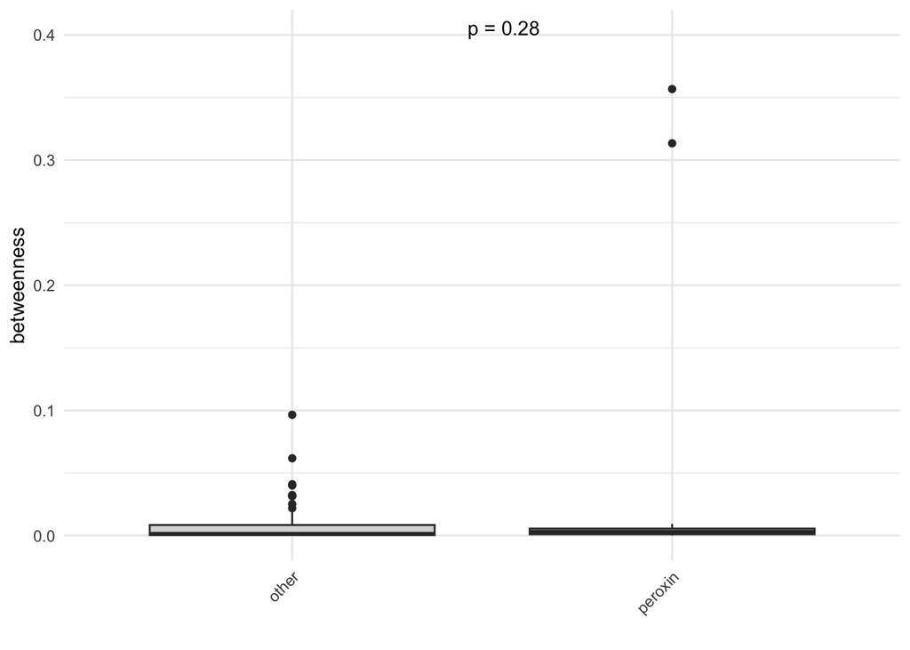

```r
#plot betweenness centrality of peroxins vs other pex proteins
pex_between <- as_tibble(rownames_to_column(as.data.frame(betweenness(pex_graph, normalized = TRUE)), var="symbol")) %>% dplyr::rename("betweenness" = `betweenness(pex_graph, normalized = TRUE)`)

fun_pl <- fun_genes %>%
  mutate(gene_class = if_else(symbol %in% peroxins, "peroxin", "other")) %>%
  dplyr::select(symbol, gene_class) %>%
  unique() %>%
  left_join(pex_between, by = join_by(symbol == symbol))

p <- fun_pl %>%
  filter(!is.na(betweenness)) %>%
  ggplot(aes(x = gene_class, y=betweenness)) +
  geom_boxplot(aes(fill = gene_class), stat="boxplot") +
  scale_fill_manual(values = col_peroxins) +
  theme_minimal() +
  theme(axis.text.x = element_text(angle = 45,hjust = 1,vjust = 1), legend.position = "none") +
  labs(x = "") +
  stat_compare_means(method = "wilcox.test", label.x = 1.5, label.y = 0.4, label = "p.format")

p
```

```r
ggsave("output/figure1/between_boxplot.pdf", plot = p, width = 3.5, height = 5.5, units = "cm", scale = 1.6)
```

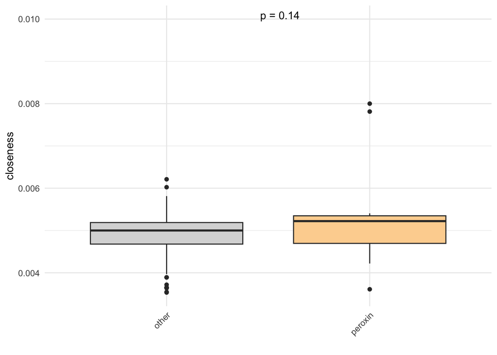

```r
pex_closeness <- as_tibble(rownames_to_column(as.data.frame(closeness(pex_graph)), var="symbol")) %>% dplyr::rename("closeness" = `closeness(pex_graph)`)

fun_pl <- fun_genes %>%
  mutate(gene_class = if_else(symbol %in% peroxins, "peroxin", "other")) %>%
  dplyr::select(symbol, gene_class) %>%
  unique() %>%
  left_join(pex_closeness, by = join_by(symbol == symbol))

p <- fun_pl %>%
  filter(!is.na(closeness)) %>%
  ggplot(aes(x = gene_class, y=closeness)) +
  geom_boxplot(aes(fill = gene_class), stat="boxplot") +
  scale_fill_manual(values = col_peroxins) +
  theme_minimal() +
  theme(axis.text.x = element_text(angle = 45,hjust = 1,vjust = 1), legend.position = "none") +
  labs(x = "") +
  stat_compare_means(method = "wilcox.test", label.x = 1.5, label.y = 0.01, label = "p.format")

p
```

```r
ggsave("output/figure1/closeness_boxplot.pdf", plot = p, width = 3.5, height = 5.5, units = "cm", scale = 1.6)
```

Fig 2: Homooliogmerisation Compare homomers of UCRinteractome with homomers in ePI. Is there a statistical significant difference?

```r
#UCRinteractome nodes 15631 (without ePI 15619)
#UCRinteractome selfloops 2137
#ePI nodes 173
#ePI selfloops (with iBRET) 78

xtab <- as.table(rbind(c(2137, 78), c(13494, 95)))
dimnames(xtab) <- list(homomers = c("Yes", "No"), interactome=c("UCR","ePI"))

library(rstatix)
homo_p <- fisher_test(xtab, detailed=TRUE)
homo_p
```

```
## # A tibble: 1 × 8
##       n estimate        p conf.low conf.high method         alternative p.signif
## * <dbl>    <dbl>    <dbl>    <dbl>     <dbl> <chr>          <chr>       <chr>
## 1 15804    0.193 2.93e-23    0.141     0.265 Fisher's Exac… two.sided   ****
```

Comparison without bret data

```r
xtab_2 <- as.table(rbind(c(2137, 47), c(13494, 126)))
dimnames(xtab_2) <- list(homomers = c("Yes", "No"), interactome=c("UCR","ePI_withoutBRET"))
library(rstatix)

homo_p_withoutBRET <- fisher_test(xtab_2, detailed=TRUE)
homo_p_withoutBRET
```

```
## # A tibble: 1 × 8
##       n estimate          p conf.low conf.high method       alternative p.signif
## * <dbl>    <dbl>      <dbl>    <dbl>     <dbl> <chr>        <chr>       <chr>
## 1 15804    0.425 0.00000355    0.300     0.609 Fisher's Ex… two.sided   ****
```

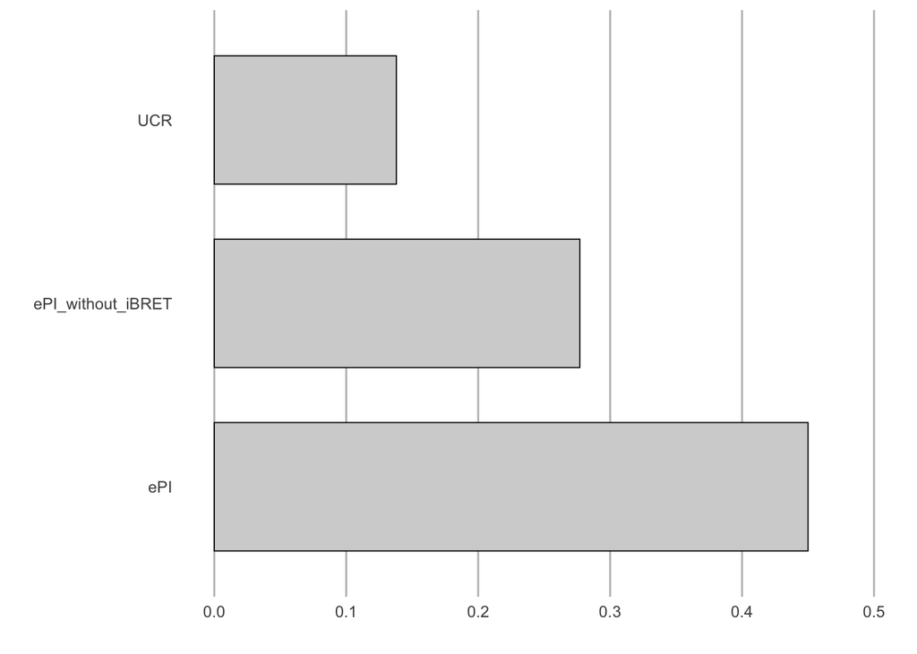

```r
homo_plot <- tibble(freq = c(0.138, 0.450, 0.277), interactome = c("UCR", "ePI", "ePI_without_iBRET")) %>%
  ggplot(aes(x = interactome, y = freq)) +
  geom_bar(stat="identity", fill="#D3D3D3", color="black", width=0.7, linewidth=0.3) +
  theme_minimal() +
  theme(panel.border = element_rect(linetype = "blank", fill = NA),
        panel.grid = element_line(colour = "white"),
        panel.grid.major.x = element_line(colour = "grey")) +
  labs(x = "", y = "") +
  scale_y_continuous(limits = c(0,0.5)) +
  coord_flip()
homo_plot
```

```r
ggsave("output/figure2/homomers_compare.pdf", plot = homo_plot, width = 5, height = 2.5, units = "cm", scale = 1.5)
```

Are non-peroxins enriched in homooligomers?

```r
ePI_edge_cl %>% filter(proteinA == proteinB) %>% mutate(function_class = if_else(proteinA %in% peroxins, "peroxin", "non-peroxin")) %>% group_by(function_class) %>% summarise(n=n())
```

```
## # A tibble: 2 × 2
##   function_class     n
##   <chr>          <int>
## 1 non-peroxin       68
## 2 peroxin           10
```

```r
#peroxins n = 16
xtab_peroxin <- as.table(rbind(c(10, 65), c(6, 90)))
dimnames(xtab_peroxin) <- list(homomers = c("Yes", "No"), function_c=c("peroxin","non-peroxin"))

fisher_test(xtab_peroxin)
```

```
## # A tibble: 1 × 3
##       n     p p.signif
## * <dbl> <dbl> <chr>
## 1   171 0.184 ns
```

How is the ePI connected to the human interactome?

```r
#load data from Julia with internal / external degree per ePI protein
ePI_in_out_degree <- read_csv(my_intExt_degree_file, show_col_types = FALSE) %>%
  dplyr::rename("Entrez" = "...1", "degree" = "overall degree", "degree_int" = "internal degree", "degree_ext" = "external degree")
#merch with yifrach_genes
ePI_in_out_degree %>% left_join(yifrach_genes, by=join_by(symbol == Gene))
```

```
## # A tibble: 174 × 7
##    Entrez degree degree_int degree_ext symbol DetectionFrequency FinalScore
##     <dbl>  <dbl>      <dbl>      <dbl> <chr>  <chr>                   <dbl>
##  1  11264      6          6          0 PXMP4  High                       28
##  2   9217     48          0         48 VAPB   Low                         2
##  3   9218     58          3         55 VAPA   Low                         2
##  4   2053      8          5          3 EPHX2  High                       26
##  5  10247     12          2         10 RIDA   Low                         4
##  6  10247     12          2         10 RIDA   Low                         3
##  7  55825     14         14          0 PECR   High                       24
##  8   8729      5          0          5 GBF1   Low                         4
##  9   3098     14          2         12 HK1    Low                         4
## 10   3099      5          0          5 HK2    Low                         4
## # ℹ 164 more rows
```

```r
require("ggrepel")
```

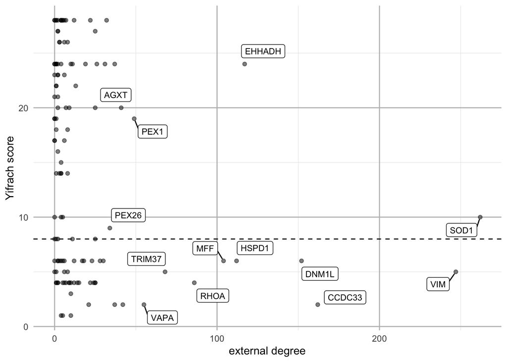

```r
p<- ePI_in_out_degree %>%
  left_join(yifrach_genes, by=join_by(symbol == Gene)) %>%
  filter(degree_int > 0) %>%
  ggplot(aes(x = degree_ext, y = FinalScore)) +
  geom_point(alpha=0.5) +
  geom_hline(yintercept = 8, linetype = "dashed") +
  geom_label_repel(aes(label = symbol),
                  size = 3,
                  box.padding = unit(0.35, "lines"),
                  point.padding = unit(0.3, "lines"),
                  max.overlaps = 6) +
  labs(x = "external degree", y = "Yifrach score") +
  theme_minimal() +
  theme(panel.grid.major = element_line(colour = "grey"))

ggsave("output/figure2/degree_out.pdf", plot = p, width = 6, height = 3, units = "cm", scale = 2)
p
```

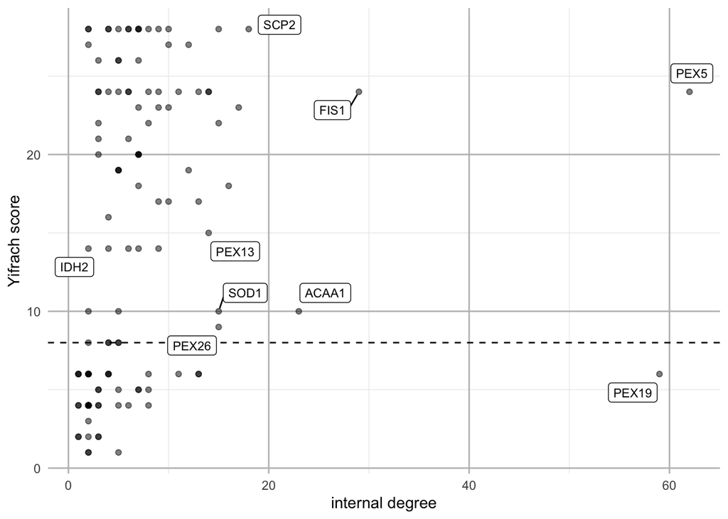

```r
require("ggrepel")
p<- ePI_in_out_degree %>%
  left_join(yifrach_genes, by=join_by(symbol == Gene)) %>%
  filter(degree_int > 0) %>%
  ggplot(aes(x = degree_int, y = FinalScore)) +
  geom_point(alpha=0.5) +
  geom_hline(yintercept = 8, linetype = "dashed") +
  geom_label_repel(aes(label = symbol),
                  size = 3,
                  box.padding = unit(0.35, "lines"),
                  point.padding = unit(0.3, "lines"),
                  max.overlaps = 6) +
  labs(x = "internal degree", y = "Yifrach score") +
  theme_minimal() +
  theme(panel.grid.major = element_line(colour = "grey"))

ggsave("output/figure2/degree_in.pdf", plot = p, width = 6, height = 3, units = "cm", scale = 2)
p
```

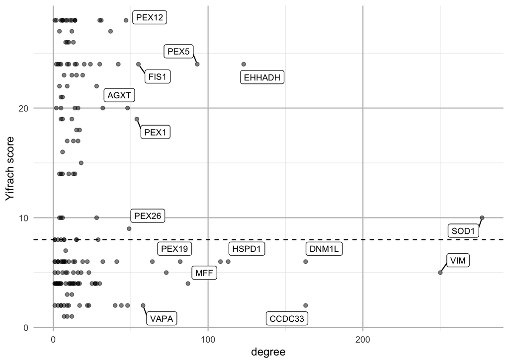

```r
require("ggrepel")
p<- ePI_in_out_degree %>%
  left_join(yifrach_genes, by=join_by(symbol == Gene)) %>%
  filter(degree > 0) %>%
  ggplot(aes(x = degree, y = FinalScore)) +
  geom_point(alpha=0.5) +
  geom_hline(yintercept = 8, linetype = "dashed") +
  geom_label_repel(aes(label = symbol),
                  size = 3,
                  box.padding = unit(0.35, "lines"),
                  point.padding = unit(0.3, "lines"),
                  max.overlaps = 6) +
  labs(x = "degree", y = "Yifrach score") +
  theme_minimal() +
  theme(panel.grid.major = element_line(colour = "grey"))

ggsave("output/figure2/degree_yifrach.pdf", plot = p, width = 6, height = 3, units = "cm", scale = 2)
p
```